# Objects in R: Introduction to R Data Structures

## R Data Structures

- Vectors
  - Atomic vector — a collection of values
  - Factors — special vectors that represent categorical data
- Matrix — a special vector with rows and columns
- Data frame — a special data structure of rows and columns, the default structure for reading in “excel-like” files
- List — a vector of different data types (including other vectors)

## R Variables are Objects

- The variables in R are technically known as objects
  - Objects should have meaningful names
  - Try to avoid common function names such as mean and sqrt or else it gets confusing
- Object names CANNOT start with a number
- Object names CAN have “.” and numbers within them
- Avoid “_”

**Variables (objects) can be created by = or <-**

```r
x <- 'abc'
x = 'abc'
x
```

```
## [1] "abc"
```

**Determine data type of a variable**

```r
typeof(x)
```

```
## [1] "character"
```

**Determine the number of variables in a variable**

```r
length(x)
```

```
## [1] 1
```

*1*

**Determine the number of characters in a variable**

```r
nchar(x)
```

```
## [1] 3
```

### R Data Types

- Character
  - “a”, “abc”,”hello world”
- Numeric (double or integer)
  - 1, 10.3, -199
- Logical
  - TRUE, FALSE
- Complex
  - 1+4i

**These data types allow you to know what sort of functions can be performed**

```r
1 + 2
```

```
## [1] 3
```

### Determine data types

```r
x <- 4
typeof(x)
```

```
## [1] "double"
```

```r
x <- 4
y <- 4.8
typeof(y)
```

```
## [1] "double"
```

```r
x+y
```

```
## [1] 8.8
```

*These data types allow you to know what sort of functions can be performed*

```r
x <- 'a'
typeof(x)
```

```
## [1] "character"
```

```r
y <- 'Hello There'
typeof(y)
```

```
## [1] "character"
```

**For example numbers can be added but characters can’t be**

```r
x <- 'a'
y <- 'Hello There'
#x+y
```

```r
x <- TRUE
typeof(x)
```

```
## [1] "logical"
```

```r
y <- FALSE
typeof(y)
```

```
## [1] "logical"
```

```r
x <- 1+4i
typeof(x)
```

```
## [1] "complex"
```

```r
x <- c(1:4)
typeof(x)
```

```
## [1] "integer"
```

### Basic Arithmetic

**Numbers in R need not be given object names**

```r
20+3
```

```
## [1] 23
```

```r
20-3
```

```
## [1] 17
```

```r
20*3
```

```
## [1] 60
```

```r
20*3
```

```
## [1] 60
```

```r
20/3
```

```
## [1] 6.666667
```

```r
20^3
```

```
## [1] 8000
```

**Remainder of the Division**

```r
20 %% 3
```

```
## [1] 2
```

**Integer of the Division**

```r
20 %/% 3
```

```
## [1] 6
```

```r
z <- 3*3
sqrt(z)
```

```
## [1] 3
```

```r
x <- 20
y <- 3
x + y
```

```
## [1] 23
```

```r
x - y
```

```
## [1] 17
```

```r
x * y
```

```
## [1] 60
```

```r
x / y
```

```
## [1] 6.666667
```

```r
x ^ y
```

```
## [1] 8000
```

```r
x %% y
```

```
## [1] 2
```

```r
x %/% y #(integer of the division)
```

```
## [1] 6
```

## Built-In Functions

- Built-in functions are operations that one can “perform” on object that are available in R
- User-defined functions are functions that are written by the user
- Packages are R functions that are written by the R community that need to be loaded before using them

### Getting Help with Functions

- R Help
  - help()
  - ?
- The help() function and ? help operator in R provide access to the documentation pages for R functions, data sets, and other objects, both for packages in the standard R distribution and for contributed packages.
- To access documentation for the standard lm (linear model)
  - help(lm)
  - help(“lm”)
  - ?lm
  - ?“lm” (i.e., the quotes are optional).
- To access help for a function in a package that’s not currently loaded, specify in addition the name of the package: for the rlm() (robust linear model) function in the MASS package:
  - help(rlm, package=“MASS”)

### Built-In Math Functions

| Function | Description |
| --- | --- |
| abs(x) | absolute value |
| sqrt(x) | square root |
| ceiling(x) | ceiling(3.475) is 4 |
| floor(x) | floor(3.475) is 3 |
| trunc(x) | trunc(5.99) is 5 |
| round(x, digits=n) | round(3.475, digits=2) is 3.48 |
| signif(x, digits=n) | signif(3.475, digits=2) is 3.5 |
| cos(x), sin(x), tan(x) | also acos(x), cosh(x), acosh(x), etc. |
| log(x) | natural logarithm |
| log10(x) | common logarithm |
| exp(x) | e^x |

**absolute value**

```r
x <- -2
abs(x)
```

```
## [1] 2
```

**square root**

```r
x <- 4
sqrt(x)
```

```
## [1] 2
```

**Rounding and Creating Integers**

```r
x <- 4.693959
n <- 3
ceiling(x)
```

```
## [1] 5
```

```r
floor(x)
```

```
## [1] 4
```

```r
trunc(x)
```

```
## [1] 4
```

*4*

```r
round(x, digits=n)
```

```
## [1] 4.694
```

*4.694*

```r
signif(x, digits=n)
```

```
## [1] 4.69
```

**Triganometry**

```r
x <- 60
cos(x)
```

```
## [1] -0.952413
```

```r
x <- 60
sin(x)
```

```
## [1] -0.3048106
```

```r
tan(x)
```

```
## [1] 0.3200404
```

**Logarithms and Exponents**

```r
x <- 3.2
log(x)
```

```
## [1] 1.163151
```

```r
log10(x)
```

```
## [1] 0.50515
```

```r
exp(x)
```

```
## [1] 24.53253
```

## Built In Statistical Functions

### Means, Medians, Ranges and Other Basic Functions on Number Sets

```r
x <- 1:20
mean(x)
```

```
## [1] 10.5
```

```r
sd(x)
```

```
## [1] 5.91608
```

```r
median(x)
```

```
## [1] 10.5
```

```r
min(x)
```

```
## [1] 1
```

```r
max(x)
```

```
## [1] 20
```

```r
quantile(x)
```

```
##    0%   25%   50%   75%  100%
##  1.00  5.75 10.50 15.25 20.00
```

```r
range(x)
```

```
## [1]  1 20
```

```r
sum(x)
```

```
## [1] 210
```

```r
diff(x, lag=1)
```

```
##  [1] 1 1 1 1 1 1 1 1 1 1 1 1 1 1 1 1 1 1 1
```

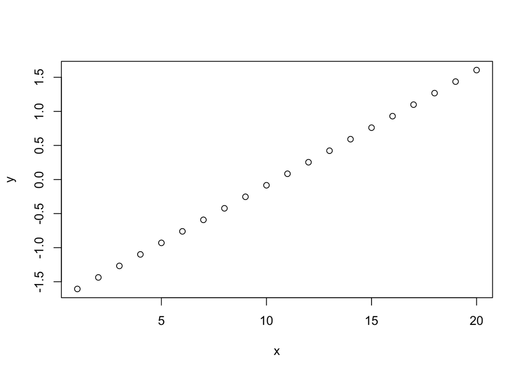

```r
y <- scale(x, center=TRUE, scale=TRUE)
plot(x,y)
```

### Normal Distribution

- dnorm(x)
- pnorm(q)
- qnorm(p)
- rnorm(n, m=0,sd=1)

**normal density function (by default m=0 sd=1)**

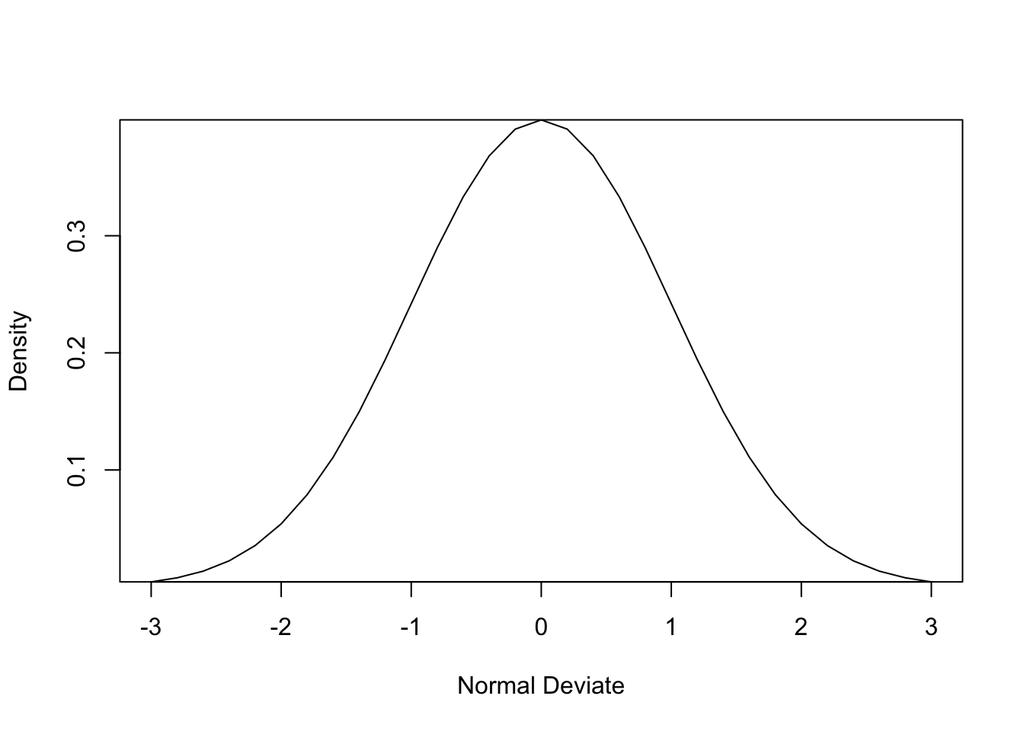

```r
x <- pretty(c(-3,3), 30)
y <- dnorm(x)
plot(x, y, type='l', xlab="Normal Deviate", ylab="Density", yaxs="i")
```

**cumulative normal probability for q**

```r
pnorm(1.96)
```

```
## [1] 0.9750021
```

**normal quantile: value at the p percentile of normal distribution**

```r
qnorm(.9)
```

```
## [1] 1.281552
```

**n random normal deviates with mean m and standard deviation sd. 50 random normal variates with mean=50, sd=10**

```r
x <- rnorm(50, m=50, sd=10)
x
```

```
##  [1] 52.86384 55.32216 56.58047 43.85826 53.81378 70.49114 34.76746
##  [8] 39.05354 42.03797 46.42519 51.48481 59.67880 45.09970 46.08792
## [15] 51.69941 51.19643 54.06850 43.98318 45.06754 52.32476 51.43550
## [22] 57.10833 40.36471 34.36543 60.57323 55.07779 54.07506 62.29781
## [29] 64.43970 40.09274 36.88292 51.24336 56.71946 46.61454 35.30518
## [36] 40.90015 49.42374 61.87528 76.13131 40.97651 53.15805 64.58313
## [43] 64.99491 51.60045 50.06395 44.19864 42.67975 45.52232 41.61571
## [50] 46.29797
```

### Binomial Distribution

binomial distribution where size is the sample size and prob is the probability of a heads (for a coin toss)

- dbinom(x, size, prob)
- pbinom(q, size, prob)
- qbinom(p, size, prob)
- rbinom(n, size, prob)

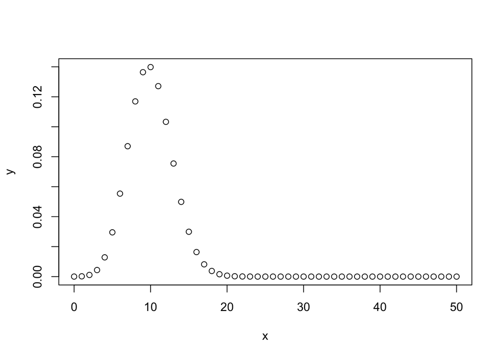

```r
x <- seq(0,50,by=1)
y <- dbinom(x,50,0.2)
plot(x,y)
```

### Poisson Distribution

poisson distribution with m=std=lamda

- dpois(x, lamda)
- ppois(q, lamda)
- qpois(p, lamda)
- rpois(n, lamda)

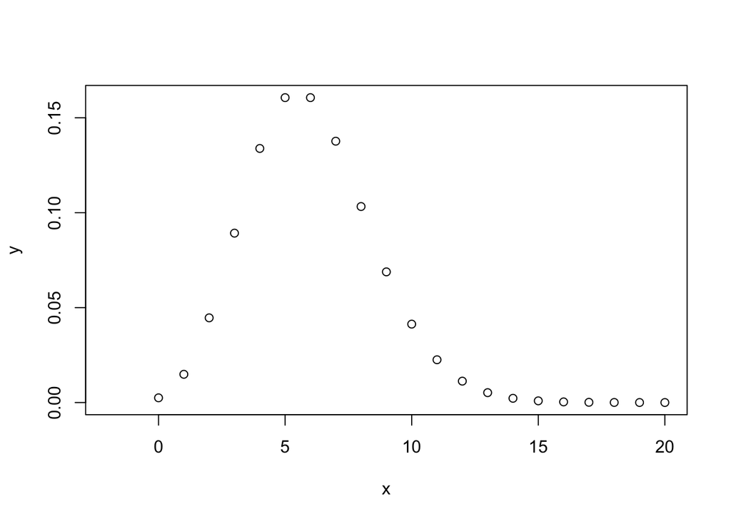

```r
x <- 0:20
y <- dpois( x=0:20, lambda=6 )
plot(x, y, xlim=c(-2,20))
```

### Uniform Distribution

- dunif(x, min=0, max=1)
- punif(q, min=0, max=1)
- qunif(p, min=0, max=1)
- runif(n, min=0, max=1)

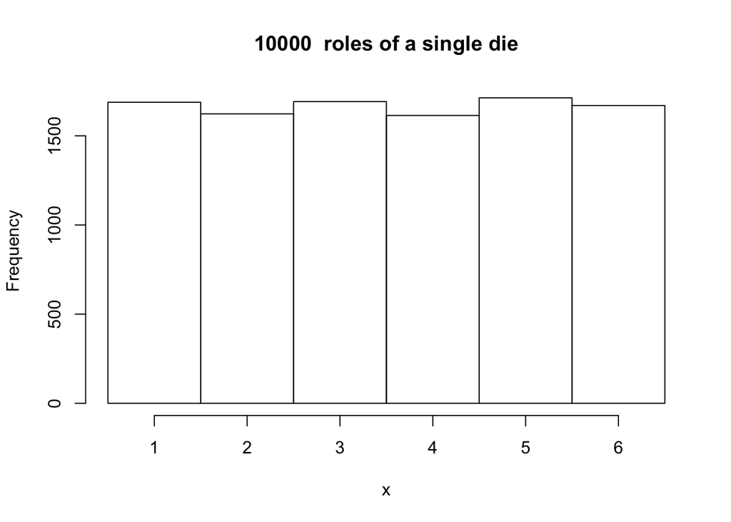

```r
numcases <- 10000
min <- 1
max <- 6
x <- as.integer(runif(numcases,min,max+1))
hist(x,main=paste( numcases," roles of a single die"),breaks=seq(min-.5,max+.5,1))
```

### Built-In String Functions

| Function | Description |
| --- | --- |
| substr(x, start=n1, stop=n2) | Extract or replace substrings in a character vector. |
| grep(pattern, x , ignore.case=FALSE, fixed=FALSE) | Search for pattern in x. If fixed =FALSE then pattern is a regular expression. If fixed=TRUE then pattern is a text string. Returns matching indices. |
| sub(pattern, replacement, x, ignore.case =FALSE, fixed=FALSE) | Find pattern in x and replace with replacement text. If fixed=FALSE then pattern is a regular expression. |
| strsplit(x, split) | Split the elements of character vector x at split. |
| paste(…, sep=“”) | Concatenate strings after using sep string to seperate them |
| toupper(x) | Uppercase |
| tolower(x) | Lowercase |

### String Manipulation

**Concatenate strings after using sep string to seperate them.**

```r
a <- "Hello"
b <- 'How'
c <- "are you? "
paste(a,b,c)
```

```
## [1] "Hello How are you? "
```

```r
paste(a,b,c, sep = "-")
```

```
## [1] "Hello-How-are you? "
```

```r
paste(a,b,c, sep = "", collapse = "")
```

```
## [1] "HelloHoware you? "
```

```r
paste('x',1:3,sep="")
```

```
## [1] "x1" "x2" "x3"
```

```r
paste('x',1:3,sep="M")
```

```
## [1] "xM1" "xM2" "xM3"
```

```r
paste('Today is', date())
```

```
## [1] "Today is Tue Dec 24 07:26:57 2019"
```

**Text Capitalization: Create Upper and Lowercase strings**

```r
a <- 'hEllo'
toupper(a)
```

```
## [1] "HELLO"
```

```r
tolower(a)
```

```
## [1] "hello"
```

**Extract or replace substrings in a character vector.**

```r
substring(a,1,2)
```

```
## [1] "hE"
```

```r
substring(a,2,5)
```

```
## [1] "Ello"
```

```r
x <- "abcdef"
substr(x, 2, 4)
```

```
## [1] "bcd"
```

**grep**

*Search for pattern in x. If fixed =FALSE then pattern is a regular expression. If fixed=TRUE then pattern is a text string. Returns matching indices.*

```r
grep("A", c("b","A","c"), fixed=TRUE)
```

```
## [1] 2
```

**substitution**

*Find pattern in x and replace with replacement text. If fixed=FALSE then pattern is a regular expression. If fixed = T then pattern is a text string.*

```r
sub("\\s",".","Hello There")
```

```
## [1] "Hello.There"
```

**Split the elements of character vector x at split.**

```r
strsplit("abc", "")
```

```
## [[1]]
## [1] "a" "b" "c"
```

### Other Built in Functions

| Function | Description |
| --- | --- |
| seq(from , to, by) | generate a sequence |
| rep(x, ntimes | repeat x n times |
| cut(x, n) | cut divides the range of x into intervals and codes the values in x according to which interval they fall. The leftmost interval corresponds to level one, the next leftmost to level two and so on. |

**generate a sequence**

```r
seq(1,10,2)
```

```
## [1] 1 3 5 7 9
```

**Repeat a string**

```r
rep("a",3)
```

```
## [1] "a" "a" "a"
```

**divide continuous variable in factor with n levels**

```r
y <- cut(1:20, 20)
y
```

```
##  [1] (0.981,1.95] (1.95,2.9]   (2.9,3.85]   (3.85,4.8]   (4.8,5.75]
##  [6] (5.75,6.7]   (6.7,7.65]   (7.65,8.6]   (8.6,9.55]   (9.55,10.5]
## [11] (10.5,11.4]  (11.4,12.4]  (12.4,13.3]  (13.3,14.3]  (14.3,15.2]
## [16] (15.2,16.2]  (16.2,17.1]  (17.1,18.1]  (18.1,19.1]  (19.1,20]
## 20 Levels: (0.981,1.95] (1.95,2.9] (2.9,3.85] (3.85,4.8] ... (19.1,20]
```

### Vectors and Matrices

A vector can be a “collection” of values or a single value

- Atomic vector
  - a collection of values
- Factors
  - special vectors that represent categorical data
- Matrix
  - special vector with rows and columns
- Data frame
  - a special data structure of rows and columns, the default structure for reading in “excel-like” files
- List
  - a vector of different data types (including other vectors)

**Vectors**

*An example of a numeric vector*

```r
x <- 1
x
```

```
## [1] 1
```

```r
y <- c(1:10)
y
```

```
##  [1]  1  2  3  4  5  6  7  8  9 10
```

```r
length(y)
```

```
## [1] 10
```

```r
typeof(y)
```

```
## [1] "integer"
```

**Vectors can be any datatype (character, logical, complex)**

```r
x <- c('a','b','c','d','e')
x
```

```
## [1] "a" "b" "c" "d" "e"
```

```r
typeof(x)
```

```
## [1] "character"
```

**For Numerical Vectors you can do comparisons**

```r
x <- c(1:10)
x
```

```
##  [1]  1  2  3  4  5  6  7  8  9 10
```

```r
x > 3
```

```
##  [1] FALSE FALSE FALSE  TRUE  TRUE  TRUE  TRUE  TRUE  TRUE  TRUE
```

```r
(x > 3) & (x < 8)
```

```
##  [1] FALSE FALSE FALSE  TRUE  TRUE  TRUE  TRUE FALSE FALSE FALSE
```

```r
x[x > 3]
```

```
## [1]  4  5  6  7  8  9 10
```

**Comparisons are logical objects**

```r
typeof((x > 3) & (x < 8))
```

```
## [1] "logical"
```

**Combining Vectors**

```r
x <- c(1:10)
x <- c(x,11:20)
x
```

```
##  [1]  1  2  3  4  5  6  7  8  9 10 11 12 13 14 15 16 17 18 19 20
```

**Performing Math on Vectors**

```r
x <- c(1:10)
x*3
```

```
##  [1]  3  6  9 12 15 18 21 24 27 30
```

```r
x[4]
```

```
## [1] 4
```

### Factors Are Nominal Vectors

The factor stores the nominal values as a vector of integers in the range [ 1… k ] and an internal vector of character strings (the original values) mapped to these integers.

```r
genotype <- c(rep("WT",5),rep("KO",5))
factor(genotype)
```

```
##  [1] WT WT WT WT WT KO KO KO KO KO
## Levels: KO WT
```

```r
genotype <- factor(genotype,levels=c("WT","KO"))
genotype
```

```
##  [1] WT WT WT WT WT KO KO KO KO KO
## Levels: WT KO
```

```r
summary(genotype)
```

```
## WT KO
##  5  5
```

## Matrix

**special vector with rows and columns**

- All columns in a matrix must have the same mode(numeric, character, etc.) and the same length. The general format is:
- mymatrix <- matrix(vector, nrow=r, ncol=c, byrow=FALSE)
- byrow=TRUE indicates that the matrix should be filled by rows.
- byrow=FALSE indicates that the matrix should be filled by columns (the default)

```r
y <- matrix(1:20, nrow=5,ncol=4)
y
```

```
##      [,1] [,2] [,3] [,4]
## [1,]    1    6   11   16
## [2,]    2    7   12   17
## [3,]    3    8   13   18
## [4,]    4    9   14   19
## [5,]    5   10   15   20
```

```r
cells <- c(1,26,24,68)
rnames <- c("R1", "R2")
cnames <- c("C1", "C2")
x <- matrix(cells, nrow=2, ncol=2, byrow=TRUE, dimnames=list(rnames, cnames))
x
```

```
##    C1 C2
## R1  1 26
## R2 24 68
```

```r
x[,1] # 1st column of matrix
```

```
## R1 R2
##  1 24
```

```r
x[2,] # 2nd row of matrix
```

```
## C1 C2
## 24 68
```

```r
x[2,1] # row 2, column 1
```

```
## [1] 24
```

```r
x[1,2]
```

```
## [1] 26
```

## Functions to Combine and Calculate Statistics on Matrices

- cbind(A,B,…)
  - Combine matrices(vectors) horizontally. Returns a matrix.
- rbind(A,B,…)
  - Combine matrices(vectors) vertically. Returns a matrix.
- rowMeans(A)
  - Returns vector of row means.
- rowSums(A)
  - Returns vector of row sums.
- colMeans(A)
  - Returns vector of column means.
- colSums(A)
  - Returns vector of column sums.
- t(A)
  - Transpose

```r
y <- matrix(1:20, nrow=5,ncol=4,byrow = FALSE)
y
```

```
##      [,1] [,2] [,3] [,4]
## [1,]    1    6   11   16
## [2,]    2    7   12   17
## [3,]    3    8   13   18
## [4,]    4    9   14   19
## [5,]    5   10   15   20
```

```r
y <- matrix(1:20, nrow=5,ncol=4,byrow = TRUE)
y
```

```
##      [,1] [,2] [,3] [,4]
## [1,]    1    2    3    4
## [2,]    5    6    7    8
## [3,]    9   10   11   12
## [4,]   13   14   15   16
## [5,]   17   18   19   20
```

```r
t(y) #transpose
```

```
##      [,1] [,2] [,3] [,4] [,5]
## [1,]    1    5    9   13   17
## [2,]    2    6   10   14   18
## [3,]    3    7   11   15   19
## [4,]    4    8   12   16   20
```

```r
rowSums(y)
```

```
## [1] 10 26 42 58 74
```

```r
colMeans(y)
```

```
## [1]  9 10 11 12
```

**Math with Matrices**

```r
y*4
```

```
##      [,1] [,2] [,3] [,4]
## [1,]    4    8   12   16
## [2,]   20   24   28   32
## [3,]   36   40   44   48
## [4,]   52   56   60   64
## [5,]   68   72   76   80
```

```r
y*y
```

```
##      [,1] [,2] [,3] [,4]
## [1,]    1    4    9   16
## [2,]   25   36   49   64
## [3,]   81  100  121  144
## [4,]  169  196  225  256
## [5,]  289  324  361  400
```

```r
y/y
```

```
##      [,1] [,2] [,3] [,4]
## [1,]    1    1    1    1
## [2,]    1    1    1    1
## [3,]    1    1    1    1
## [4,]    1    1    1    1
## [5,]    1    1    1    1
```

| Function | Description |
| --- | --- |
| A * B | Element-wise multiplication |
| A %*% B | Matrix multiplication |
| A %o% B | Outer product. AB’ |
| crossprod(A,B) | A’B |
| crossprod(A) | A’A |
| t(A) | Transpose |
| diag(x) | Creates diagonal matrix with elements of x in the principal diagonal |
| diag(A) | Returns a vector containing the elements of the principal diagonal |
| diag(k) | If k is a scalar, this creates a k x k identity matrix. Go figure. |
| solve(A, b) | Returns vector x in the equation b = Ax (i.e., A-1b) |
| solve(A) | Inverse of A where A is a square matrix. |

# Data Frames

- A special data structure of rows and columns, the default structure for reading in “excel-like” files
- A data frame is more general than a matrix, in that different columns can have different modes (numeric, character, factor, etc.). This is similar to SAS and SPSS datasets.

```r
d <- c(1,2,3,4)
e <- c("red", "white", "red", NA)
f <- c(TRUE,TRUE,TRUE,FALSE)
x <- data.frame(d,e,f)
names(x) <- c("ID","Color","Passed")
x
```

```
##   ID Color Passed
## 1  1   red   TRUE
## 2  2 white   TRUE
## 3  3   red   TRUE
## 4  4  <NA>  FALSE
```

```r
setwd("~/Downloads/DataStructureLecture")
tbl <- read.csv(file="sample_example_R1_data_structures.csv",header=TRUE)
tbl
```

```
##      SampleID      Tissue SampleGroup SubjectID     Organism     Race
## 1  SRR1551074 Whole.Blood whole_blood        53 Homo sapiens    White
## 2  SRR1551073 Whole.Blood          NK        53 Homo sapiens    White
## 3  SRR1551072 Whole.Blood         CD8        53 Homo sapiens    White
## 4  SRR1551071 Whole.Blood         CD4        53 Homo sapiens    White
## 5  SRR1551070 Whole.Blood     B-Cells        53 Homo sapiens    White
## 6  SRR1551069 Whole.Blood   monocytes        53 Homo sapiens    White
## 7  SRR1551068 Whole.Blood neutrophils        53 Homo sapiens    White
## 8  SRR1551060 Whole.Blood whole_blood        21 Homo sapiens    White
## 9  SRR1551059 Whole.Blood          NK        21 Homo sapiens    White
## 10 SRR1551058 Whole.Blood         CD8        21 Homo sapiens    White
## 11 SRR1551057 Whole.Blood         CD4        21 Homo sapiens    White
## 12 SRR1551056 Whole.Blood     B-Cells        21 Homo sapiens    White
## 13 SRR1551055 Whole.Blood   monocytes        21 Homo sapiens    White
## 14 SRR1551054 Whole.Blood neutrophils        21 Homo sapiens    White
```

[output cut: 101 more lines]

```r
tbl[3:5]
```

```
##    SampleGroup SubjectID     Organism
## 1  whole_blood        53 Homo sapiens
## 2           NK        53 Homo sapiens
## 3          CD8        53 Homo sapiens
## 4          CD4        53 Homo sapiens
## 5      B-Cells        53 Homo sapiens
## 6    monocytes        53 Homo sapiens
## 7  neutrophils        53 Homo sapiens
## 8  whole_blood        21 Homo sapiens
## 9           NK        21 Homo sapiens
## 10         CD8        21 Homo sapiens
## 11         CD4        21 Homo sapiens
## 12     B-Cells        21 Homo sapiens
## 13   monocytes        21 Homo sapiens
## 14 neutrophils        21 Homo sapiens
## 15 whole_blood        20 Homo sapiens
## 16          NK        20 Homo sapiens
## 17         CD8        20 Homo sapiens
## 18         CD4        20 Homo sapiens
## 19     B-Cells        20 Homo sapiens
## 20   monocytes        20 Homo sapiens
## 21 neutrophils        20 Homo sapiens
## 22          NK        44 Homo sapiens
## 23         CD8        44 Homo sapiens
## 24         CD4        44 Homo sapiens
## 25     B-Cells        44 Homo sapiens
## 26   monocytes        44 Homo sapiens
## 27 neutrophils        44 Homo sapiens
## 28 whole_blood        44 Homo sapiens
```

```r
tbl[c("SampleID","Tissue")]
```

```
##      SampleID      Tissue
## 1  SRR1551074 Whole.Blood
## 2  SRR1551073 Whole.Blood
## 3  SRR1551072 Whole.Blood
## 4  SRR1551071 Whole.Blood
## 5  SRR1551070 Whole.Blood
## 6  SRR1551069 Whole.Blood
## 7  SRR1551068 Whole.Blood
## 8  SRR1551060 Whole.Blood
## 9  SRR1551059 Whole.Blood
## 10 SRR1551058 Whole.Blood
## 11 SRR1551057 Whole.Blood
## 12 SRR1551056 Whole.Blood
## 13 SRR1551055 Whole.Blood
## 14 SRR1551054 Whole.Blood
## 15 SRR1551053 Whole.Blood
## 16 SRR1551052 Whole.Blood
## 17 SRR1551051 Whole.Blood
## 18 SRR1551050 Whole.Blood
## 19 SRR1551049 Whole.Blood
## 20 SRR1551048 Whole.Blood
## 21 SRR1551047 Whole.Blood
## 22 SRR1550991 Whole.Blood
## 23 SRR1550990 Whole.Blood
## 24 SRR1550989 Whole.Blood
## 25 SRR1550988 Whole.Blood
## 26 SRR1550987 Whole.Blood
## 27 SRR1550986 Whole.Blood
## 28 SRR1550981 Whole.Blood
```

```r
tbl$Gender
```

```
##  [1] female female female female female female female female female female
## [11] female female female female female female female female female female
## [21] female female female female female female female female
## Levels: female
```

```r
tbl[tbl$SampleGroup == 'monocytes',]
```

```
##      SampleID      Tissue SampleGroup SubjectID     Organism     Race
## 6  SRR1551069 Whole.Blood   monocytes        53 Homo sapiens    White
## 13 SRR1551055 Whole.Blood   monocytes        21 Homo sapiens    White
## 20 SRR1551048 Whole.Blood   monocytes        20 Homo sapiens    White
## 26 SRR1550987 Whole.Blood   monocytes        44 Homo sapiens Hispanic
##      SampleName Gender
## 6  53_Monocytes female
## 13 21_Monocytes female
## 20 20_Monocytes female
## 26 44_Monocytes female
##                                                FullPathToFqR1
## 6  /project/BICF/s166458/pipeline_devel/SRR1551069_1.fastq.gz
## 13 /project/BICF/s166458/pipeline_devel/SRR1551055_1.fastq.gz
## 20 /project/BICF/s166458/pipeline_devel/SRR1551048_1.fastq.gz
## 26 /project/BICF/s166458/pipeline_devel/SRR1550987_1.fastq.gz
##                                                FullPathToFqR2
## 6  /project/BICF/s166458/pipeline_devel/SRR1551069_2.fastq.gz
## 13 /project/BICF/s166458/pipeline_devel/SRR1551055_2.fastq.gz
## 20 /project/BICF/s166458/pipeline_devel/SRR1551048_2.fastq.gz
## 26 /project/BICF/s166458/pipeline_devel/SRR1550987_2.fastq.gz
```

```r
subset(x=tbl,SampleGroup == 'monocytes',select=c('Tissue','SampleID'))
```

```
##         Tissue   SampleID
## 6  Whole.Blood SRR1551069
## 13 Whole.Blood SRR1551055
## 20 Whole.Blood SRR1551048
## 26 Whole.Blood SRR1550987
```

```r
setwd("~/Downloads/DataStructureLecture")
tbl1 <- read.csv(file="sample_example_R1_data_structures.csv",header=TRUE)
tbl2 <- read.csv(file="table2.csv",header=TRUE)
tbl2
```

```
##      SampleID SubjectID BMI
## 1  SRR1551074        53  23
## 2  SRR1551073        53  23
## 3  SRR1551072        53  23
## 4  SRR1551071        53  23
## 5  SRR1551070        53  23
## 6  SRR1551069        53  23
## 7  SRR1551068        53  23
## 8  SRR1551060        21  28
## 9  SRR1551059        21  28
## 10 SRR1551058        21  28
## 11 SRR1551057        21  28
## 12 SRR1551056        21  28
## 13 SRR1551055        21  28
## 14 SRR1551054        21  28
## 15 SRR1551053        20  35
## 16 SRR1551052        20  35
## 17 SRR1551051        20  35
## 18 SRR1551050        20  35
## 19 SRR1551049        20  35
## 20 SRR1551048        20  35
## 21 SRR1551047        20  35
## 22 SRR1550991        44  40
## 23 SRR1550990        44  40
## 24 SRR1550989        44  40
## 25 SRR1550988        44  40
## 26 SRR1550987        44  40
## 27 SRR1550986        44  40
## 28 SRR1550981        44  40
```

## DataFrame Functions

- gives a very brief description of the data
  - str(df)
- gives the name of each variables
  - names(df)
- gives some very basic summary statistics for each variable
  - summary(df)
- shows the first few rows
  - head(df)
- shows the last few rows.
  - tail(df)
- looks at duplicated elements and returns a logical vector. You can use table() to summarize this vector.
  - duplicated()
- keeps only the unique lines in a dataset
  - unique()

```r
merge.tbl <- merge(tbl1,tbl2,by='SampleID')
merge.tbl
```

```
##      SampleID      Tissue SampleGroup SubjectID.x     Organism     Race
## 1  SRR1550981 Whole.Blood whole_blood          44 Homo sapiens Hispanic
## 2  SRR1550986 Whole.Blood neutrophils          44 Homo sapiens Hispanic
## 3  SRR1550987 Whole.Blood   monocytes          44 Homo sapiens Hispanic
## 4  SRR1550988 Whole.Blood     B-Cells          44 Homo sapiens Hispanic
## 5  SRR1550989 Whole.Blood         CD4          44 Homo sapiens Hispanic
## 6  SRR1550990 Whole.Blood         CD8          44 Homo sapiens Hispanic
## 7  SRR1550991 Whole.Blood          NK          44 Homo sapiens Hispanic
## 8  SRR1551047 Whole.Blood neutrophils          20 Homo sapiens    White
## 9  SRR1551048 Whole.Blood   monocytes          20 Homo sapiens    White
## 10 SRR1551049 Whole.Blood     B-Cells          20 Homo sapiens    White
## 11 SRR1551050 Whole.Blood         CD4          20 Homo sapiens    White
## 12 SRR1551051 Whole.Blood         CD8          20 Homo sapiens    White
## 13 SRR1551052 Whole.Blood          NK          20 Homo sapiens    White
## 14 SRR1551053 Whole.Blood whole_blood          20 Homo sapiens    White
```

[output cut: 130 more lines]

```r
help('merge')
```

## Lists

An ordered collection of objects (components). A list allows you to gather a variety of (possibly unrelated) objects under one name.

```r
w <- list(name="Fred", mynumbers=a, mymatrix=y, age=5.3)
w
```

```
## $name
## [1] "Fred"
##
## $mynumbers
## [1] "hEllo"
##
## $mymatrix
##      [,1] [,2] [,3] [,4]
## [1,]    1    2    3    4
## [2,]    5    6    7    8
## [3,]    9   10   11   12
## [4,]   13   14   15   16
## [5,]   17   18   19   20
##
## $age
## [1] 5.3
```

# Workspace Functions

- lists the objects in your workspace
  - ls()
- removes an object in your workspace
  - rm(object1,object2)
- removes all objects in your workspace
  - rm(list=ls())
- saves R objects to a file
  - save(object1,object2,file=“file.RData”)
- load an R object from a file
  - load(“file.Rdata”)
- find current working directory
  - getwd()
- set working directory
  - setwd(‘C:/workingDirectory’) #
- quit
  - quit()
- list all packages available to load
  - library()
- load package
  - library(package)
  - require(package)
- Install Packages
  - install.packages(“ggplot2”)
  - source(“http://bioconductor.org/biocLite.R”)
  - biocLite(“DESeq2”)